# **Not So Sunny Southern California:** Classifying Drought Conditions in Los Angeles County, California

**Nick Vastine**  
DTSA 5742 - Predicting Extreme Climate Behavior with Machine Learning  
Final Project  
March 3, 2025

## Abstract

Wildfires in Southern California at the start of 2025 accounted for the 2nd and 3rd most destructive wildfires in California's history ("Top 20 Most Destructive California Wildfires" *Cal FIRE*). In the densely populated Los Angeles County with increasing frequent drought conditions, it is valuable to understand the underlying indicators to accurately classify drought conditions.

This report considers temperature, soil moisture, and groundwater data from USGS, NOAA, and US Drought Monitor to build binary drought classification models. Data was imported, cleaned, aggregated, and standardized prior to model training. A binary drought classification metric was developed, though future work could perform regression on the Drought Severity and Coverage Index (DSCI).

Principal Component Analysis (PCA) was performed not to reduce dimensionality, but instead to identify soil temperature and moisture as similar predictors in the first principal component.

While many models performed at 90%+ accuracy, the random forest ensemble method performed best with 98.4% accuracy. Models were also investigated for the most important predictors to drought classification, which was primarily groundwater level followed by soil temperature.

These models are limited in application to Los Angeles Country and rely on assuming that future drought will reflect historic conditions. Further analysis could consider regression analysis on DSCI, consider predictive modeling from current conditions, and experiment further with model tuning such as by varying hyperparameters or exploring neural network implementations.

## Contents

0. **Introduction**
1. **Methodology**
   1. Data Sourcing
   2. Unsupervised Learning - PCA
   3. Model preparation
      1. Standardizing
      2. Train/Test Split
   4. Supervised Learning - Classification
      1. Decision Tree
      2. Random Forest
      3. Logistic Regression
      4. Neural Network
2. **Results**
   1. Key predictors
   2. Supervised Learning Accuracy Comparison
3. **Limitations**
   1. Training Data
   2. Predictive Modeling
4. **Conclusion**
5. **References**

## 0. Introduction

Wildfires across Southern California in early 2025 were ranked among the worst in California history (“Statistics.” *Cal FIRE*). In 2025 alone, more than 57,000 acres have burned, claimed 29 lives, and 16,000 structures have been destroyed ("The Department of Forestry and Fire Protection" *Cal FIRE*). Of the top 20 most destructive wildfires in California history, 15 have occured in the past 10 years ("Top 20 Most Destructive California Wildfires" *Cal FIRE*).

With the dramatic loss of life and property from these wildfire events, it is valuable to classify drought conditions in Southern California via a model. Los Angeles county has a population of 9.663 million people, which is greater than 40 states in the United States ("QuickFacts Los Angeles County, California." *United States Census Bureau*). Thus, investigating an area where drought can affect millions of individuals is valuable for policy decisions or resource management.

This analysis seeks to understand the indicators of drought drawing from numerous government data sources to accurate classify drought conditions via supervised learning.

## 1. Methodology

The drought analysis of Los Angeles County occurs in several steps, from API data collection through comparative analysis of supervised learning methods.

First, data is collected, cleaned, and aggregated from several government data sources. Exploratory data analysis is performed at each data import to identify any trends and adjust for any suspicious data.

Once data is collected, a Principal Component Analysis (PCA) is performed to analyze feature similarity. Since there are relatively few features to describe our drought conditions, PCA is performed solely as an exploratory study and does not create features for supervised learning.

Data is then split into a testing and training set. This study also assesses the effect of standardized features on model performance, so a scaled training/testing set is also created.

Five supervised learning methods are compared to identify the classification model with the highest accuracy. These methods include: decision tree, random forest, logistic classification, support vector machines, and neural networks. Methods are implemented with default settings where available. A sensitivity study is performed on neural network architecture, evaluating different neuron counts in 1 or 2 layer networks.

### 1.0 Package Dependencies

Many standard packages such as `pandas`, `numpy`, and `matplotlib` will be used in this project. The following code also uses the `dataretrieval` API for US Geological Survey (USGS) sites and `requests` for HTTP requests from the National Oceanic and Atmospheric Association (NOAA).

```python
import requests
import dataretrieval.nwis as nwis # USGS Import
import pandas as pd
import numpy as np
# import matplotlib
import matplotlib.pyplot as plt
import seaborn as sns
import datetime
```

```python
from sklearn.preprocessing import StandardScaler
from sklearn.decomposition import PCA
from sklearn.model_selection import train_test_split
```

### 1.1 Data Sourcing

The indicators for this analysis are sourced from several government sources.

- Groundwater Level in San Bernardino (USGS) - [USGS Site 340804117221604](https://waterdata.usgs.gov/monitoring-location/340804117221604/#dataTypeId=continuous-72019-0&period=P7D&showMedian=true)
- Streamflow of the Los Angeles River (USGS) - [USGS Site 11092450](https://waterdata.usgs.gov/monitoring-location/11092450/#dataTypeId=continuous-00060-0&period=P365D&showMedian=false)
- Soil Moisture and Temperature in Santa Barbara (NOAA) - [Climate Reference Network](https://www.ncei.noaa.gov/data/us-climate-reference-network/access/derived-products/soil/soilanom/)
- Precipitation and Atmosphere Temperature at LAX (NOAA) - [NOAA Station USW00023174](https://www.ncdc.noaa.gov/cdo-web/datasets/GHCND/stations/GHCND:USW00023174/detail)
- Drought Conditions in LA County (Drought Monitor) - [Comprehensive Statistics](https://droughtmonitor.unl.edu/DmData/DataDownload/ComprehensiveStatistics.aspx)

#### 1.1.1 Groundwater Level

Groundwater level is sourced from a US Geological Survey site. While technically there are no USGS stations measuring groundwater within Los Angeles county, there are groundwater measurements in the neighboring city of San Bernardino.

[USGS Site 340804117221604](https://waterdata.usgs.gov/monitoring-location/340804117221604/#dataTypeId=continuous-72019-0&period=P7D&showMedian=true) is imported below using the NWIS Data Retrieval API. The data is then cleaned to isolate the date and median groundwater features, and null values are removed.

A summary plot is presented below the imported information. Note that groundlevel may appear misleading since a receding water level appears as an increase in the groundwater plot. As such, the plot shows a gradually receding groundwater level in San Bernardino without major seasonal variation. A histogram accompanies the plots, which indicates a stagnating water level in recent years.

```python
# Groundwater - Data Retrieval
sites = ['340804117221604']
df_gwl = nwis.get_record(sites=sites,
                         service='dv',
                         start='2010-01-01',
                         end='2024-12-31').reset_index() # Daily values
df_gwl.reset_index()
df_gwl = df_gwl[['datetime','72019_Median']]    # Isolate relevant information
df_gwl['datetime'] = df_gwl['datetime'].dt.date # Clean up dates
df_gwl.columns = ['date','gwl']                 # Rename for ease
df_gwl.dropna(inplace=True)
# df_gwl.head(2)
# df_gwl.to_parquet('data/gwl_data/los_angeles.parquet')
```

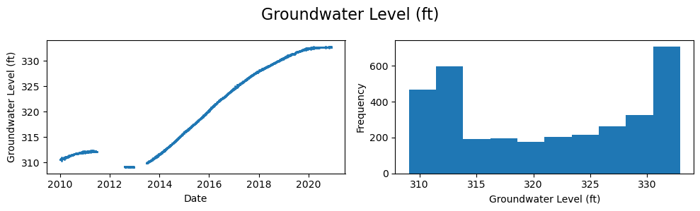

```python
## Plotting
fig, ax = plt.subplots(1,2, figsize=(10,3),tight_layout=True)
fig.suptitle("Groundwater Level (ft)", fontsize=16)
# Groundwater vs. Date
ax[0].plot(df_gwl['date'],df_gwl['gwl'],'o',markersize=1)
ax[0].set_xlabel('Date')
ax[0].set_ylabel('Groundwater Level (ft)')
# Histogram
ax[1].hist(df_gwl['gwl'])
ax[1].set_xlabel('Groundwater Level (ft)')
ax[1].set_ylabel('Frequency')
```

#### 1.1.2 Streamflow

It is challenging to identify a suitable streamflow site since many of Los Angeles' waterways are dammed to limit flow, thus measuring the flow above or below the dam could lead to different conclusions. For example, flow measurements upstream of the dam may represent preciptitation more directly, while measurements downstream of the dam may instead reflect drought expectations (i.e. downstream flow is fully restricted if drought is expected). There is additional streamflow nuance considering water rights and how much water must be passed through a dam, even under local drought conditions.

After reviewing some site options, the report collects streamflow information from [USGS Site 11092450](https://waterdata.usgs.gov/monitoring-location/11092450/#dataTypeId=continuous-00060-0&period=P365D&showMedian=false). This site is directly on the Los Angeles River and has consistently available data since 2002. The site also collected a variety of information such as dissolved oxygen, pH, phycocyanin fluorescence... indicating the site's importance.

The below code imports the data, isolates relevant information, removes null values, then plots the streamflow information. Interestingly, the plot appears to show some seasonality, with a significant spike in discharge at least once per year. The accompanying histogram also indicates the generally low average discharge, which has been labeled with a red dashed line.

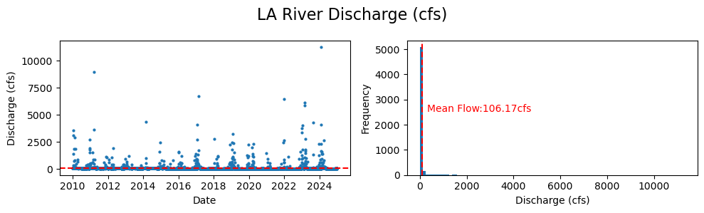

```python
# Streamflow - Data Retrieval
sites = ['11092450']
df_flow = nwis.get_record(sites=sites,
                          service='dv',
                          start='2010-01-01',
                          end='2024-12-31').reset_index() # Daily values
df_flow.reset_index()
df_flow = df_flow[['datetime','00060_Mean']]      # Isolate relevant information
df_flow['datetime'] = df_flow['datetime'].dt.date # Clean up dates
df_flow.columns = ['date','discharge']            # Rename for ease
df_flow.dropna(inplace=True)
# df_flow.head(2)
# df_flow.to_parquet('data/los_angeles_streamflow.parquet')

## Plotting
fig, ax = plt.subplots(1,2, figsize=(10,3),tight_layout=True)
fig.suptitle("LA River Discharge (cfs)", fontsize=16)
# Discharge vs. Date - with average
ax[0].plot(df_flow['date'],df_flow['discharge'],'o', markersize=2)
ax[0].set_xlabel('Date')
ax[0].set_ylabel('Discharge (cfs)')
ax[0].axhline(df_flow.discharge.mean(), color='red', linestyle='dashed')
# Discharge Histogram - with average
ax[1].hist(df_flow['discharge'],bins = 100)
ax[1].set_xlabel('Discharge (cfs)')
ax[1].set_ylabel('Frequency')
ax[1].axvline(df_flow.discharge.mean(), color='red', linestyle='dashed')
ax[1].text(df_flow.discharge.mean() + 200,
           2500,
           'Mean Flow:'+ str(round(df_flow.discharge.mean(),2)) + 'cfs', color='red')
```

#### 1.1.3 Soil Moisture and Soil Temperature

Soil Moisture and Temperature information is collected from the National Oceanic and Atmospheric Administration (NOAA) using HTTP requests. Note there is limited data available in Los Angeles County, so soil data is captured from the neighboring city of Santa Barbara.

The below code imports the dataset, then isolates the Soil Moisture Volumetric Water Content (SMVWC) and Soil Temperature at depths of 10, 20, and 50 cm. SMVWC represents the volume of water per unit volume of soil, ranging from 0.0 (0% water) to 1.0 (100% water). These features are labeled `sm_Xcm` and `st_Xcm` respectively, where X denotes the soil depth of the measurement.

The data is then plotted, first separately showing the moisture and temperature at a range of depths over time. The data is then plotted together, grouping moisture and temperature data.

```python
# Data sourced from NOAA - https://www.ncei.noaa.gov/data/us-climate-reference-network/access/derived-products/soil/soilanom/
csv_url = 'https://www.ncei.noaa.gov/data/us-climate-reference-network/access/derived-products/soil/soilanom/CRNSSM0101-CA_Santa_Barbara_11_W.csv'
df_soil = pd.read_csv(csv_url)

# Isolate Soil Moisture Volumetric Water Content (SMVWC) and Soil Temperature (ST)
# at 10, 20, and 50 cm depths
df_soil = df_soil[['DATE_TIME',
                   'SMVWC_10_CM', 'ST_10_CM',
                   'SMVWC_20_CM', 'ST_20_CM',
                   'SMVWC_50_CM', 'ST_50_CM']]
df_soil['DATE_TIME'] = pd.to_datetime(df_soil['DATE_TIME'],  # Clean up dates
                                      format='%Y%m%d%H')
df_soil['DATE_TIME'] = df_soil['DATE_TIME'].dt.date
df_soil = df_soil.groupby('DATE_TIME').mean().reset_index()  # Average multiple entries
df_soil.dropna(inplace=True)                                 # Drop null
df_soil.rename(columns={'DATE_TIME': 'date',                 # Rename for ease
                            'SMVWC_10_CM': 'sm_10cm', 'ST_10_CM': 'st_10cm',
                            'SMVWC_20_CM': 'sm_20cm', 'ST_20_CM': 'st_20cm',
                            'SMVWC_50_CM': 'sm_50cm', 'ST_50_CM': 'st_50cm'}, inplace=True)
# Soil Temperature at X depth (st_Xcm), Soil Moisture at X depth (sm_Xcm)
df_soil.reset_index()
df_soil.head(1)
```

|  | date | sm_10cm | st_10cm | sm_20cm | st_20cm | sm_50cm | st_50cm |
| --- | --- | --- | --- | --- | --- | --- | --- |
| 0 | 2011-03-01 | 0.314 | 10.77619 | 0.337762 | 11.157143 | 0.470952 | 11.685714 |

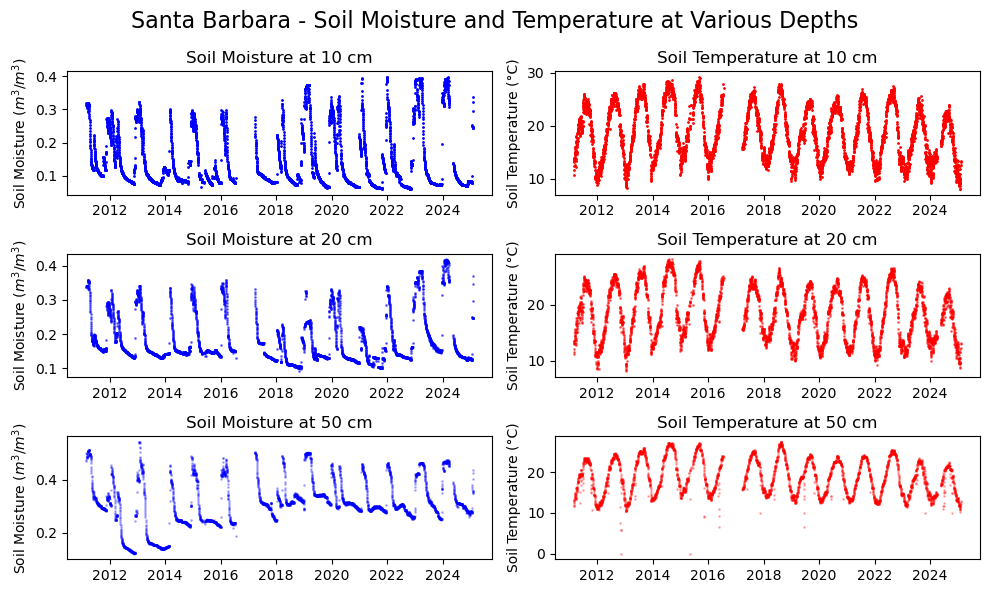

```python
# Subplots for Soil Moisture and Temperature at various depths.
fig, axes = plt.subplots(3, 2, figsize=(10,6),tight_layout=True)
fig.suptitle("Santa Barbara - Soil Moisture and Temperature at Various Depths", fontsize=16)
vars = list(df_soil.columns)
vars.pop(0)
axes = axes.ravel()
depths = ['10 cm','10 cm','20 cm','20 cm','50 cm','50 cm']
alphas = [1,1,0.5,0.5,0.25,0.25]
for ax,var,depth,alpha in zip(axes,vars,depths,alphas):
    if 'st' not in var:
        color  = 'blue'
        title  = 'Soil Moisture at ' + str(depth)
        ylabel = 'Soil Moisture ($m^3/m^3$)'
    else:
        color  = 'red'
        title  = 'Soil Temperature at ' + str(depth)
        ylabel = 'Soil Temperature (°C)'
    ax.plot(df_soil['date'],df_soil[var], 'o', markersize=1 ,color = color, alpha = alpha)
    ax.set_ylabel(ylabel)
    ax.set_title(title)
```

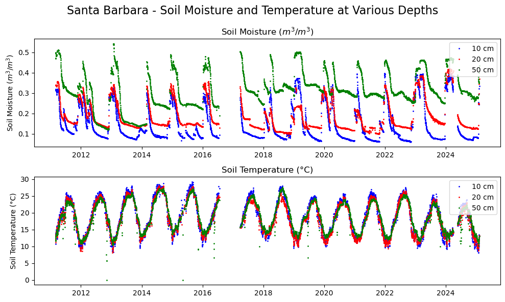

```python
# Subplots for Soil Moisture and Temperature at various depths.
fig, axes = plt.subplots(2, 1, figsize=(10,6), tight_layout=True)
fig.suptitle("Santa Barbara - Soil Moisture and Temperature at Various Depths", fontsize=16)
vars = ['sm_10cm', 'sm_20cm', 'sm_50cm', 'st_10cm', 'st_20cm', 'st_50cm']
colors = ['blue','red','green']
axes = axes.ravel()
depths = ['10 cm','20 cm','50 cm']

for i in range(len(vars)):
    ax = axes[i//3]
    if i // 3 == 0:
        title  = 'Soil Moisture ($m^3/m^3$)'
    else:
        title  = 'Soil Temperature (°C)'
    ax.plot(df_soil['date'],df_soil[vars[i]],'o', markersize=1, label = depths[i%3], color = colors[i%3])
    ax.set_ylabel(title)
    ax.set_title(title)
    ax.legend(loc='upper right')
```

The above plot indicates that soil temperature does not have significant variance at the different depths, with the exception of the occasional outlier. This similarity is further reinforced using a correlation matrix below, indicating strong correlation between the soil temperatures.

```python
df_soil[['st_10cm', 'st_20cm', 'st_50cm']].corr()
```

|  | st_10cm | st_20cm | st_50cm |
| --- | --- | --- | --- |
| st_10cm | 1.000000 | 0.988107 | 0.946158 |
| st_20cm | 0.988107 | 1.000000 | 0.952127 |
| st_50cm | 0.946158 | 0.952127 | 1.000000 |

While features will not be reduced manually (for example, averaging the three soil temperature features to a single feature), it will be interesting to see the similarity of these features during Principal Component Analysis.

#### 1.1.4 Temperature and Precipitation

Temperature and precipitation data is collected from NOAA, though this time from their [NCEI Data Service API](https://www.ncei.noaa.gov/support/access-data-service-api-user-documentation).

The Los Angeles International Airport, [NOAA Station USW00023174](https://www.ncdc.noaa.gov/cdo-web/datasets/GHCND/stations/GHCND:USW00023174/detail), was selected as it includes mostly complete data for temperature and precipitation. The following code imports the data since 2010 through the end of 2024.

```python
## NOAA NCEI Import
# ** Due to API record limits, data is imported incrementally and consolidated **

# Generate date list for incremental export
date_list = []
for year in range(2010,2025):
    for month_start,month_end in [("-01-01","-06-30"),("-07-01","-12-31")]:
        date_list.append((str(year)+month_start,str(year)+month_end))
# Station
station = ['GHCND:USW00023174']
# HTTP Requests
url = 'https://www.ncei.noaa.gov/cdo-web/api/v2/data'
headers = {'token':'HQvmpIfClwoToZoPmOrIxNNvqqstpWXm'} # Passed in requests
# Initialize dataframe
df_NOAA = pd.DataFrame()
# Import incrementally, by date
for start,end in date_list:
#    print("Current Date Import: ",start,end)
    # HTTP Request
    payload = {'datasetid':'GHCND','stationid':station,'startdate':start, 'enddate':end, 'datatypeid':['TMAX','TMIN','PRCP'], 'limit':1000, 'units':'standard'}
    r = requests.get(url, params=payload, headers=headers)
    while r.status_code == 503: # Check for server unavailable
        print("Request Error: ", r.status_code)
        r = requests.get(url, params=payload, headers=headers) # re-run request if server was unavailable until it works
    r.raise_for_status()  # raises exception when not a 2xx response
    # Processing Request
    data = r.json()
    live_df = pd.json_normalize(data['results']) # Data is imported such that each station/date/item is its own line
    grouped_df = live_df.groupby(['station','date', 'datatype'])['value'].first().unstack().reset_index()
        # groupby() put values in station/date/datatype order.
        # first() takes the first value of each group (if there were redundancies)
        # unstack() pivots from long to wide format based on the datatype
    # Saving data
    df_NOAA = pd.concat([df_NOAA, grouped_df], ignore_index = True) # Add to running total
    #df_NOAA.to_csv("NOAA Data Export.csv")
print("Import Complete!")
#df_NOAA.to_csv("NOAA Data Export - Complete.csv")
```

```
Request Error:  503
Import Complete!
```

After importing the data, we can perform further cleaning such as renaming columns and re-encoding our date information.

```python
## NOAA Clean-up
df_NOAA = df_NOAA[['date','PRCP','TMAX','TMIN']]
df_NOAA['date'] = pd.to_datetime(df_NOAA['date'])
df_NOAA['date'] = df_NOAA['date'].dt.date
df_NOAA.head(1)
```

| datatype | date | PRCP | TMAX | TMIN |
| --- | --- | --- | --- | --- |
| 0 | 2010-01-01 | 0.0 | 69.0 | 50.0 |

Next we will inspect the data for null values. Luckily no points are affected.

```python
df_NOAA.isna().sum()
```

```
datatype
date    0
PRCP    0
TMAX    0
TMIN    0
dtype: int64
```

And finally we can visualize the data, highlighting the seasonality in temperature and precipitation.

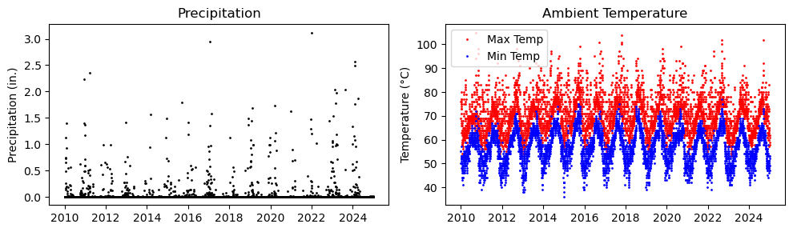

```python
fig,ax = plt.subplots(1,2,figsize=(10,3),tight_layout=True)
ax[0].plot(df_NOAA['date'], df_NOAA['PRCP'], 'o', label='Precipitation', color='black', markersize = 1)
ax[0].set_title("Precipitation")
ax[0].set_ylabel("Precipitation (in.)")
ax[1].plot(df_NOAA['date'], df_NOAA['TMAX'], 'o', label='Max Temp', color='red', markersize = 1)
ax[1].plot(df_NOAA['date'], df_NOAA['TMIN'], 'o', label='Min Temp', color='blue', markersize = 1)
ax[1].set_title("Ambient Temperature")
ax[1].set_ylabel("Temperature (°C)")
ax[1].legend()
```

#### 1.1.5 Drought Data

The final step before we can begin our model training is to establish our target data. The drought data is represented as a percentage of area falling into the following categories [[1]](https://www.drought.gov/data-maps-tools/historical-drought-data-conditions-tool)

- D4 - Exceptional Drought (0-2 percentile)
- D3 - Extreme Drought (2-5 percentile)
- D2 - Severe Drought (5-10 percentile)
- D1 - Moderate Drought (10-20 percentile)
- D0 - Abnormally Dry (20-30 percentile)
- None or 0 - Neither Wet or Dry

Drought data is downloaded from the [Drought Monitor tool web service](https://droughtmonitor.unl.edu/DmData/DataDownload/WebServiceInfo.aspx#comp) using the following parameters:

- Area = `CountyStatistics`
- Statistics Type = `GetDroughtSeverityStatisticsByAreaPercent`
- Area of Interest (AOI) = `06037`, Federal Information Processing Standard (FIPS) code for Los Angeles County
- Start Date = `1/1/2010`
- End Date = `1/1/2025`
- Statistics Format = `2`, categorical labeling rather than cumulative

A [visualization of the region](https://www.drought.gov/historical-information?dataset=0&selectedDateUSDM=20250218&state=California&countyFips=06037) can be found on the Drought Monitor website.

```python
## Drought data import
# Data source: https://droughtmonitor.unl.edu/DmData/DataDownload/ComprehensiveStatistics.aspx
# Documentation: https://droughtmonitor.unl.edu/DmData/DataDownload/WebServiceInfo.aspx#comp
# URL to modify: https://usdmdataservices.unl.edu/api/[area]/[statistics type]?aoi=[aoi]&startdate=[start date]&enddate=[end date]&statisticsType=[statistics format]
drought_url = "https://usdmdataservices.unl.edu/api/CountyStatistics/GetDroughtSeverityStatisticsByAreaPercent?aoi=06037&startdate=1/1/2010&enddate=1/1/2025&statisticsType=2"
df_drought = pd.read_csv(drought_url)
df_drought.head(1)
```

|  | MapDate | FIPS | County | State | None | D0 | D1 | D2 | D3 | D4 | ValidStart | ValidEnd | StatisticFormatID |
| --- | --- | --- | --- | --- | --- | --- | --- | --- | --- | --- | --- | --- | --- |
| 0 | 20241231 | 6037 | Los Angeles County | CA | 0.0 | 16.12 | 83.88 | 0.0 | 0.0 | 0.0 | 2024-12-31 | 2025-01-06 | 2 |

The data is provided with a `ValidStart` and `ValidEnd` date. In essence, this data is generated by recording drought conditions once each week. These conditions are assumed constant for the entire week.

Rather than isolate these single measurements using `ValidStart`, we will duplicate the weekly data point for each day within the `ValidStart` to `ValidEnd` period. This allows us to transform weekly data into daily data points, cohesive with our daily-reported predictors.

A stacked bar chart of the drought conditions is presented below the cleaned data.

```python
## Drought Data Clean-up
# Remove unnecessary columns
df_drought = df_drought.drop(['MapDate','FIPS','County','State','StatisticFormatID'], axis=1)
# Convert to date time
df_drought['ValidStart'] = pd.to_datetime(df_drought['ValidStart'])
df_drought['ValidEnd'] = pd.to_datetime(df_drought['ValidEnd'])
# Create new date column which is a list of days from ValidStart to ValidEnd
# ex. 1/1/2010 to 1/7/2010 becomes [1/1/2010, 1/2/2010, 1/3/2010, ...]
df_drought['date'] = df_drought.apply(lambda x: pd.date_range(start=x['ValidStart'], end=x['ValidEnd'], freq='D'), axis=1)
# "Explode", duplicating the row for each element in the date list.
df_drought = df_drought.explode('date')
df_drought.drop(['ValidStart','ValidEnd'], axis=1, inplace=True)
# Sorting the dataframe by date
df_drought = df_drought.sort_values(by='date')
# Dropping rows with duplicate dates
df_drought = df_drought.drop_duplicates(subset='date', keep='first')
# Resetting the index
df_drought = df_drought.reset_index(drop=True)
# Updating date object
df_drought['date'] = pd.to_datetime(df_drought['date'])
df_drought['date'] = df_drought['date'].dt.date
df_drought.to_parquet('target.parquet')
df_drought.head(2)
```

|  | None | D0 | D1 | D2 | D3 | D4 | date |
| --- | --- | --- | --- | --- | --- | --- | --- |
| 0 | 0.0 | 12.06 | 28.35 | 59.59 | 0.0 | 0.0 | 2009-12-29 |
| 1 | 0.0 | 12.06 | 28.35 | 59.59 | 0.0 | 0.0 | 2009-12-30 |

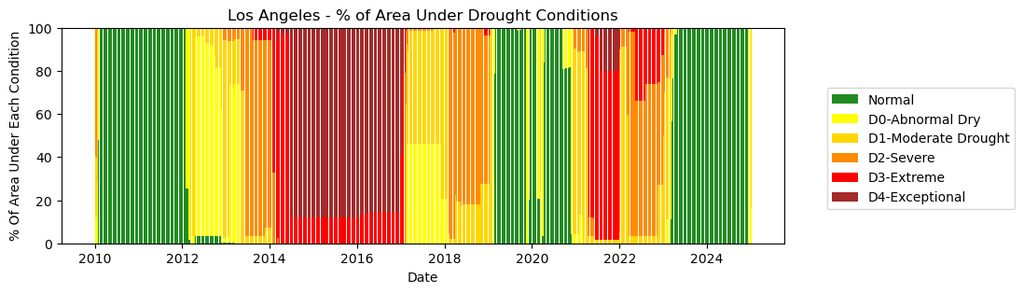

```python
## Drought Plot - % of Area Under Drought Conditions
x = df_drought['date']
y1, y2, y3, y4, y5, y6 = df_drought['None'],df_drought['D0'],df_drought['D1'], df_drought['D2'], df_drought['D3'], df_drought['D4']
plt.figure(figsize=(10,3))
plt.bar(x, y1, color='forestgreen')
plt.bar(x, y2, bottom=y1, color='yellow')
plt.bar(x, y3, bottom=y1+y2, color='gold')
plt.bar(x, y4, bottom=y1+y2+y3, color='darkorange')
plt.bar(x, y5, bottom=y1+y2+y3+y4, color='red')
plt.bar(x, y6, bottom=y1+y2+y3+y4+y5, color='brown')
plt.xlabel("Date")
plt.ylabel("% Of Area Under Each Condition")
plt.legend(["Normal", "D0-Abnormal Dry", "D1-Moderate Drought", "D2-Severe", "D3-Extreme","D4-Exceptional"],loc='upper left',bbox_to_anchor=(1.05, 0.75))
plt.title("Los Angeles - % of Area Under Drought Conditions")
plt.show()
```

We will create a binary `target` field to classify if drought is occurring. There does not appear to be a single criteria to classify a larger area as in drought. The [US Drought Monitor Drought Classification Resource](https://droughtmonitor.unl.edu/About/AbouttheData/DroughtClassification.aspx) provides example percentiles for each predictor, but does not clearly state 'if X exceeds __ %, the entire area is under drought'. Thus, I will be applying my best judgement in labeling this dataset.

The aformentioned classification resource suggests >30% of area under normal conditions is typical. Thus, we will mark any day with <30% normal or abnormally dry (D0) conditions as under drought.

```python
## Drought Labeling
df_drought['target'] = 0
df_drought.loc[(df_drought['None']+df_drought['D0']) < 30,'target'] = 1
```

Below is the drought classification plot with a secondary plot of our labeled drought conditions.

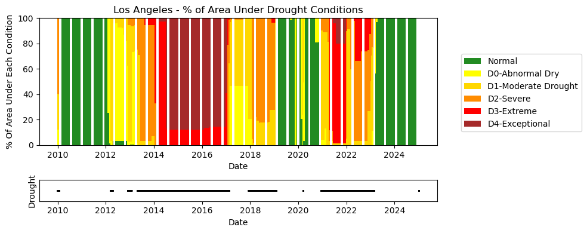

```python
## Drought Plot - Now with drought classification
fig, (ax1,ax2) = plt.subplots(2,1,figsize=(10,4), tight_layout=True,gridspec_kw={'height_ratios': [6, 1]})
ax1.bar(x, y1, color='forestgreen')
ax1.bar(x, y2, bottom=y1, color='yellow')
ax1.bar(x, y3, bottom=y1+y2, color='gold')
ax1.bar(x, y4, bottom=y1+y2+y3, color='darkorange')
ax1.bar(x, y5, bottom=y1+y2+y3+y4, color='red')
ax1.bar(x, y6, bottom=y1+y2+y3+y4+y5, color='brown')
ax1.set_xlabel("Date")
ax1.set_ylabel("% Of Area Under Each Condition")
ax1.legend(["Normal", "D0-Abnormal Dry", "D1-Moderate Drought", "D2-Severe", "D3-Extreme","D4-Exceptional"],loc='upper left',bbox_to_anchor=(1.05, 0.75))
ax1.set_title("Los Angeles - % of Area Under Drought Conditions")
ax2.scatter(df_drought[df_drought['target'] == 1]['date'], df_drought[df_drought['target'] == 1]['target'],color = 'black', s=1)
ax2.tick_params(axis='y', which='both', length=0)
ax2.set_yticks([])
ax2.set_xlabel("Date")
ax2.set_ylabel('Drought')
plt.show()
```

We will also calculate the [Drought Severity and Coverage Index (DSCI)](https://droughtmonitor.unl.edu/About/AbouttheData/DSCI.aspx) as a continuous variable to represent drought status. DSCI is a cumulative summation of the area %, with an upper limit of 500.

Unfortunately DSCI regression is not within the scope of this analysis.

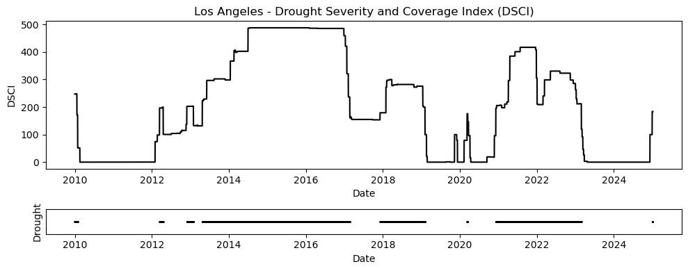

```python
## DSCI Plot
df_drought['DSCI'] = y2 + 2*y3 + 3*y4 + 4*y5 + 5*y6

fig, (ax1,ax2) = plt.subplots(2,1,figsize=(10,4), tight_layout=True, gridspec_kw={'height_ratios': [6, 1]})

ax1.plot(x, df_drought['DSCI'], color='black')
ax1.set_xlabel("Date")
ax1.set_ylabel("DSCI")
ax1.set_title("Los Angeles - Drought Severity and Coverage Index (DSCI)")
ax2.scatter(df_drought[df_drought['target'] == 1]['date'], df_drought[df_drought['target'] == 1]['target'],color = 'black',s=1)
ax2.tick_params(axis='y', which='both', length=0)
ax2.set_yticks([])
ax2.set_xlabel("Date")
ax2.set_ylabel('Drought')
plt.show()
```

#### 1.1.6 Merging Datasets

Now that all the data has been collected and formatted, we can consolidate them into a final dataframe.

```python
## Final Inspection
print(df_gwl.head(1))
print(df_flow.head(1))
print(df_soil.head(1))
print(df_NOAA.head(1))
print(df_drought.head(1))
```

```
         date     gwl
0  2010-01-01  310.58
         date  discharge
0  2010-01-01       61.3
         date  sm_10cm   st_10cm   sm_20cm    st_20cm   sm_50cm    st_50cm
0  2011-03-01    0.314  10.77619  0.337762  11.157143  0.470952  11.685714
datatype        date  PRCP  TMAX  TMIN
0         2010-01-01   0.0  69.0  50.0
   None     D0     D1     D2   D3   D4        date  target    DSCI
0   0.0  12.06  28.35  59.59  0.0  0.0  2009-12-29       1  247.53
```

```python
## Merge
df_la = df_gwl.merge(df_NOAA, on='date',how='inner')
df_la = df_la.merge(df_soil, on='date',how='inner')
df_la = df_la.merge(df_flow, on='date',how='inner')
df_la = df_la.merge(df_drought[['date','target','DSCI']], on='date',how='inner')
df_la.dropna(inplace=True)
df_la.head(1)
```

|  | date | gwl | PRCP | TMAX | TMIN | sm_10cm | st_10cm | sm_20cm | st_20cm | sm_50cm | st_50cm | discharge | target | DSCI |
| --- | --- | --- | --- | --- | --- | --- | --- | --- | --- | --- | --- | --- | --- | --- |
| 0 | 2011-03-01 | 312.22 | 0.0 | 60.0 | 45.0 | 0.314 | 10.77619 | 0.337762 | 11.157143 | 0.470952 | 11.685714 | 67.1 | 0 | 0.0 |

This data is saved to a parquet file to include with the project on Github.

```python
df_la.to_parquet('la.parquet')
```

We can also use the below cell to import our data without re-running our import processes.

```python
df_la = pd.read_parquet('la - Copy.parquet')
```

### 1.2 Unsupervised Machine Learning - Principal Component Analysis

Our final data set has 11 features, which is reasonable for our supervised learning analysis. However, we can perform Principal Component Analysis (PCA), an unsupervised machine learning technique, to understand the influence of our individual features.

First the dataset drops date, our binary drought feature, and our calculated DSCI. We then scale the data to avoid feature magnitude from biasing the PCA analysis.

```python
df_pca = df_la.copy()
df_pca.drop(['target','date','DSCI'], inplace=True, axis=1)
df_pca_scaled = StandardScaler().fit_transform(df_pca)
pca_model = PCA(n_components = 0.9, svd_solver = 'full').fit(df_pca_scaled)
```

The PCA solver determined 5 principal components are necessary to explain 90% of the variance in our data, as reflected in the below scree plot.

```
(-0.5, 5.5)
```

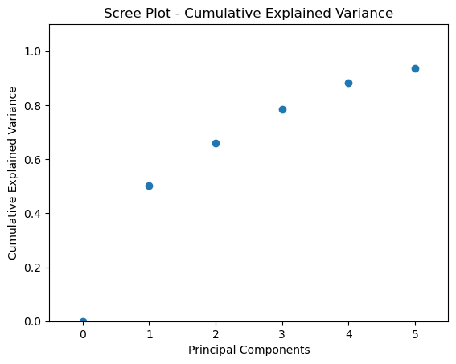

```python
x_scree = range(0,pca_model.n_components_+1)
y_scree = np.insert(pca_model.explained_variance_ratio_.cumsum(),0,0) # add 0,0 point

plt.plot(x_scree, y_scree, 'o')
plt.title("Scree Plot - Cumulative Explained Variance")
plt.xlabel("Principal Components")
plt.ylabel("Cumulative Explained Variance")
plt.ylim(0,1.1)
plt.xlim(-0.5,5.5)
```

The first few principal components will also reflect the importance of individual features by interpretting their loadings. Large magnitude loadings indicate feature importance.

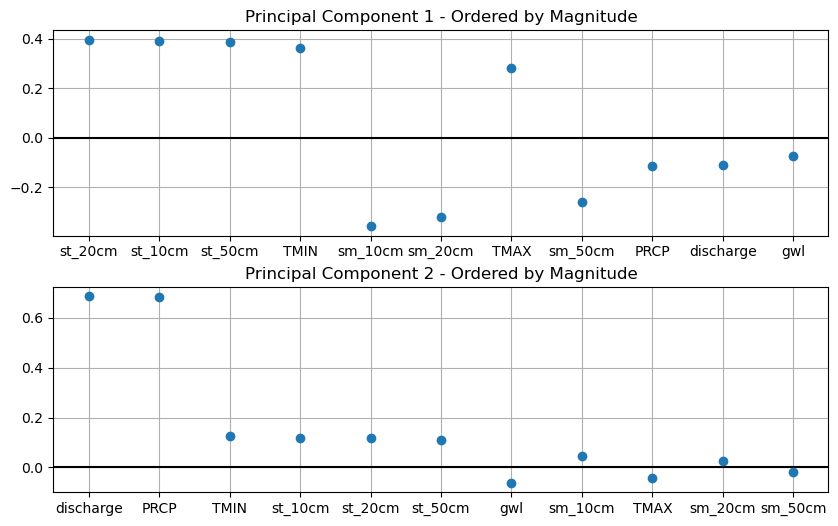

```python
pca_comp_data = list(zip(df_pca.columns,pca_model.components_[0],pca_model.components_[1]))
pca_features = pd.DataFrame(pca_comp_data,columns=['feature','importance1','importance2'])
pca_features.sort_values('importance1', ascending=False, key = abs, inplace=True)
fig, axs = plt.subplots(2,1,figsize=(10, 6))
plt.subplots_adjust(hspace=0.25)
axs[0].grid(True, which='both')
axs[0].axhline(y=0, color='k')
axs[0].plot(pca_features['feature'],pca_features['importance1'],'o')
axs[0].set_title("Principal Component 1 - Ordered by Magnitude")
pca_features.sort_values('importance2', ascending=False, key = abs, inplace=True)
axs[1].grid(True, which='both')
axs[1].axhline(y=0, color='k')
axs[1].axis('on')
axs[1].set_title("Principal Component 2 - Ordered by Magnitude")
axs[1].plot(pca_features['feature'],pca_features['importance2'],'o')
```

The above plots indicate that soil temperature, max and min temperature, and soil moisture conditions contribute significantly to describing the variation in the data and are similar features. The second principal component heavily favors streamflow discharge and precipitation to further explain variance in the data.

While these principal components are insightful for explaining overall variance, they do not necessarily reflect correlation with our target data. These components will not be used in supervised learning as there are relatively few base features to analyze.

### 1.3 Model Preparation

The data must be split into our train/test datasets for supervised model training.

Our analysis will also consider the effects of standarizing our variables to evaluate the effect on model performance.

```python
## Train/Test Split
Y = df_la['target'].copy()
X = df_la.copy()
X.drop(['date','target','DSCI'],axis=1,inplace=True)
X_train, X_test, y_train, y_test = train_test_split(X, Y, test_size = 0.2, random_state = 0)
```

```python
## Scaling
X_scaled = StandardScaler().fit_transform(X)
X_scaled_train = X_scaled[list(X_train.index)]
X_scaled_test = X_scaled[list(X_test.index)]
```

```python
## Checking Train/Test Shape
print("X Train:",X_train.shape)
print("X Test:",X_test.shape)
print("X Train Standard:",X_scaled_train.shape)
print("X Test Standard:",X_scaled_test.shape)
```

```
X Train: (2098, 11)
X Test: (525, 11)
X Train Standard: (2098, 11)
X Test Standard: (525, 11)
```

We can also confirm our test and training set have a balanced split of both classes.

```python
## Checking Class Balance
print('Train Drought %:', round(100*y_train.sum()/y_train.count(),3),'%')
print('Test Drought %:', round(100*y_test.sum()/y_test.count(),3),'%')
```

```
Train Drought %: 57.007 %
Test Drought %: 53.333 %
```

### 1.4 Supervised Learning - Classification

With our data prepared, we can begin training our various classification models. We will compare the following models. Each model will use default settings where possible.

1. Decision Trees
2. Random Forest
3. Logistic Regression
4. Support Vector Machines (SVM)
5. Neural Network

Models will be judged using accuracy, recall, and F1 score.

```python
# Classifiers
from sklearn.tree import DecisionTreeClassifier
from sklearn.ensemble import RandomForestClassifier
from sklearn.linear_model import LogisticRegression
from sklearn.svm import SVC
import tensorflow as tf
from tensorflow import keras
from keras import layers

# Accuracy Measures
from sklearn.metrics import accuracy_score
from sklearn.metrics import recall_score
from sklearn.metrics import f1_score

# Performance Measure
from time import time
```

The classifier evaluation function below takes the classifier of interest and returns the accuracy metrics in a dataframe, as well as our models for further consideration.

```python
## Classifier Eval Function
def classifier_eval(classifier,label):
    ## Model creation and fit
    # Non-standard
    model = classifier
    model.fit(X_train, y_train)
    y_model = model.predict(X_test)
    # Standard
    model_standard = classifier
    model_standard.fit(X_scaled_train, y_train)
    y_model_standard = model_standard.predict(X_scaled_test)

    ## Accuracy
    # Non-Standard
    acc = accuracy_score(y_test, y_model)
    rec = recall_score(y_test, y_model)
    f1 = f1_score(y_test, y_model)
    # Standard
    acc_standard = accuracy_score(y_test, y_model_standard)
    rec_standard = recall_score(y_test, y_model_standard)
    f1_standard = f1_score(y_test, y_model_standard)

    data_eval = {'Model':label,
               'Feature':['Original', 'Standardized'],
               'Accuracy':[acc, acc_standard],
               'Recall':[rec, rec_standard],
               'F1 Score':[f1, f1_standard]}

    df_eval = pd.DataFrame(data_eval)
    df_eval.set_index(['Model','Feature'],inplace=True)
    return df_eval, model, model_standard
```

#### 1.4.1 Decision Trees

```python
## Decision Tree Classification
classifier = DecisionTreeClassifier(random_state=42)
label = 'Decision Tree'
df_dt, dt_model, dt_standard_model = classifier_eval(classifier,label)
df_dt
```

| Model | Feature | Accuracy | Recall | F1 Score |
| --- | --- | --- | --- | --- |
| Decision Tree | Original | 0.980952 | 0.971429 | 0.981949 |
|  | Standardized | 0.980952 | 0.971429 | 0.981949 |

Note the table below, the decision tree performs well with ~98% accuracy, and the results appear unaffected by feature scaling.

We can also evaluate the dimensions of the resulting decision tree and the importance of each feature.

```python
## Decision Tree Dimensions and Importance
print("Depth:",dt_model.get_depth())
print("Number of Leaves:",dt_model.get_n_leaves())
data_dt_importance = list(zip(X.columns,dt_model.feature_importances_))
df_dt_importance = pd.DataFrame(data_dt_importance,columns=['Features','Importance'])
df_dt_importance.sort_values('Importance', ascending=False).transpose()
```

```
Depth: 10
Number of Leaves: 23
```

|  | 0 | 8 | 4 | 9 | 5 | 7 | 10 | 1 | 2 | 3 | 6 |
| --- | --- | --- | --- | --- | --- | --- | --- | --- | --- | --- | --- |
| Features | gwl | sm_50cm | sm_10cm | st_50cm | st_10cm | st_20cm | discharge | PRCP | TMAX | TMIN | sm_20cm |
| Importance | 0.869598 | 0.088019 | 0.030872 | 0.003864 | 0.003334 | 0.002371 | 0.001943 | 0.0 | 0.0 | 0.0 | 0.0 |

The feature importances indicate that groundwater level and soil moisture are most important in predicting drought conditions. While decision trees are not deterministic (ie there is variation with re-fitting the decision trees), it appears ambient temperature is less important for accurate classification. This may indicate temperature variation does not neatly correlate with Los Angeles' dramatic drought period from 2013-2016, 2018, and 2021-2022.

#### 1.4.2 Random Forest

We can compare a single decision tree with a random forest ensemble method. Random Forest incorporates a random subset of features, which may improve accuracy by incorporating ambient temperature and precipitation not used in the single decision tree.

```python
# Random Forest Classification
classifier = RandomForestClassifier(random_state=42)
label = 'Random Forest'
df_rf, rf_model, rf_standard_model = classifier_eval(classifier, label)
df_rf
```

| Model | Feature | Accuracy | Recall | F1 Score |
| --- | --- | --- | --- | --- |
| Random Forest | Original | 0.984762 | 0.978571 | 0.985612 |
|  | Standardized | 0.984762 | 0.978571 | 0.985612 |

Note the accuracy metrics are not dramatically different from our decision tree method, and both models perform well. Again our model performance is not affected by scaling our training data.

We can again evaluate the feature importance of the random forest structure. While groundwater and soil moisture are still the most important features, importance is spread across more features than the original decision tree. This is likely the result of incorporating random subsets of features in the random forest framework.

```python
# Random Forest Feature Importance
data_rf_importance = list(zip(X.columns,rf_model.feature_importances_))
df_rf_importance = pd.DataFrame(data_rf_importance,columns=['Features','Importance'])
df_rf_importance.sort_values('Importance', ascending=False).transpose()
```

|  | 0 | 8 | 6 | 9 | 7 | 5 | 4 | 10 | 3 | 2 | 1 |
| --- | --- | --- | --- | --- | --- | --- | --- | --- | --- | --- | --- |
| Features | gwl | sm_50cm | sm_20cm | st_50cm | st_20cm | st_10cm | sm_10cm | discharge | TMIN | TMAX | PRCP |
| Importance | 0.400832 | 0.214125 | 0.106514 | 0.067002 | 0.061765 | 0.057067 | 0.050362 | 0.023313 | 0.009684 | 0.006469 | 0.002868 |

#### 1.4.3 Logistic Classification

We can compare our decision tree methods to a linear logistic classification method. Note that logistic classification assumes linearity between our predictors and our target variable. Since our variables are not linear, we should expect worse performance from this model.

```python
classifier = LogisticRegression(max_iter=10000, random_state=42)
label = 'Logistic Regression'
df_log, log_model, log_standard_model = classifier_eval(classifier, label)
df_log
```

| Model | Feature | Accuracy | Recall | F1 Score |
| --- | --- | --- | --- | --- |
| Logistic Regression | Original | 0.752381 | 0.764286 | 0.767025 |
|  | Standardized | 0.758095 | 0.785714 | 0.776014 |

Our model performs much worse than our decision tree methods, with an accuracy of ~75% compared to the decision tree ~98% accuracy. Note the solver was also unable to converge with default 100 iterations setting, needing 10,000 iterations to provide stable results.

Before adjusting the max iterations, the standardized model performed better than the non-standardized model.

We are able to review the coefficients from the standardized logistic regression to understand feature importance.

```python
data_log_importance = list(zip(X.columns,log_standard_model.coef_[0]))
df_log_importance = pd.DataFrame(data_log_importance,columns=['Features','Coef'])
df_log_importance.sort_values(by='Coef', key=abs, ascending=False).transpose()
```

|  | 0 | 9 | 6 | 5 | 4 | 7 | 1 | 3 | 8 | 10 | 2 |
| --- | --- | --- | --- | --- | --- | --- | --- | --- | --- | --- | --- |
| Features | gwl | st_50cm | sm_20cm | st_10cm | sm_10cm | st_20cm | PRCP | TMIN | sm_50cm | discharge | TMAX |
| Coef | -1.163285 | 1.079321 | -0.773707 | -0.640247 | 0.5883 | -0.57813 | 0.188301 | -0.187926 | -0.179503 | -0.142514 | 0.00714 |

Again the model indicates the influence of groundwater level and soil moisture, though with more influence set to soil temperature. Ambient temperature is again less influential.

Surprisingly, soil temperature at 50cm depth has a different sign than soil temperature at 10 and 20 cm. These features are very strongly correlated (as indicated below), which may indicate flaws in the design of the model. Unfortunately this package does not provide P-values to evaluate feature significance, and will not be considered in the scope of this analysis.

```python
df_la[['st_10cm','st_20cm','st_50cm']].corr()
```

|  | st_10cm | st_20cm | st_50cm |
| --- | --- | --- | --- |
| st_10cm | 1.000000 | 0.986090 | 0.940283 |
| st_20cm | 0.986090 | 1.000000 | 0.945043 |
| st_50cm | 0.940283 | 0.945043 | 1.000000 |

#### 1.4.4 Support Vector Machine

As noted, the logistic regression classification did not perform as well as the decision trees. This may be due to the non-linearity of our predictors, which should be better captured with a support vector machine. The default `rbf` kernel should adequately capture non-linearity without user intervention.

```python
classifier = SVC()
label = 'SVC'
df_SVM, SVM_model, SVM_standard_model = classifier_eval(classifier, label)
df_SVM
```

| Model | Feature | Accuracy | Recall | F1 Score |
| --- | --- | --- | --- | --- |
| SVC | Original | 0.636190 | 1.000000 | 0.745672 |
|  | Standardized | 0.927619 | 0.967857 | 0.934483 |

While SVM improves over the logistic regression model, it does not achieve the accuracy benchmark established by the decision tree methods. It also indicates a strong difference in accuracy between the original data and scaled features, indicating the importance of feature scaling.

Also note that SVM does not provide useful importance for coefficients due to the kernel trick. Thus, we lose some insight into the model.

#### 1.4.5 Neural Network

Finally we will compare our other supervised machine learning methods to a neural network. Of course there are no 'default settings' for a neural network. As such, this section explores the effect of neural network architecture on its performance.

The following code performs a sensitivity analysis on a 2-hidden layer neural network. The first layer will include 5, 10, or 15 neurons. The second layer will include 1, 5, 10, or 15 neurons. This results in 12 combinations, including effectively collapsing the second layer to a single neuron to represent a single hidden layer network.

The neural networks will be trained for a maximum 150 epochs, sharing the default learning rate with learning rate reduction across models. Batch size will be fixed at about 5% of the training data at 100 samples.

```python
## Build Neural Network Function
def build_neural_network(n1,n2,mode='all'):
    model = keras.Sequential([
        layers.Dense(n1, activation="leaky_relu", name="layer1", kernel_initializer=tf.keras.initializers.LecunNormal()),
        layers.Dense(n2, activation="leaky_relu", name="layer2", kernel_initializer=tf.keras.initializers.LecunNormal()),
        layers.Dense(1,  activation="sigmoid",    name="Output")
    ])
    optimizer = tf.keras.optimizers.Adam(clipnorm=True)
    model.compile(optimizer=optimizer, loss='binary_crossentropy', metrics=['accuracy','recall','F1Score'])
    # Early Stopping
    es = tf.keras.callbacks.EarlyStopping(monitor='val_loss', patience=3, verbose=0, restore_best_weights=True)
    # Learning Rate Reduction
    rlrnop = tf.keras.callbacks.ReduceLROnPlateau(monitor='val_loss', patience=1, verbose=0)
    # Training
    start = time()
    log = model.fit(X_scaled_train, y_train, validation_data=(X_scaled_test, y_test), epochs=150, batch_size=100, callbacks=[es, rlrnop], verbose=0)
    duration = time()-start
    # Logging model performance
    model_loss = log.history['loss'][-1]
    model_val_loss = log.history['val_loss'][-1]
    model_acc = log.history['accuracy'][-1]
    model_val_acc = log.history['val_accuracy'][-1]
    model_val_recall = log.history['recall'][-1]
    model_val_f1 = log.history['F1Score'][-1]
    epoch = len(log.history['loss'])
    if mode == 'all':
        return model_loss, model_val_loss, model_acc, model_val_acc, epoch, duration
    else:
        return model_val_acc, model_val_recall, model_val_f1
```

```python
## Architecture Sensitivity
df_neural_architecture = pd.DataFrame(columns=['n1','n2','model_loss','model_val_loss', 'model_acc', 'model_val_acc','epoch','duration'])
for n1 in [5, 10, 15]:
    for n2 in [1, 5, 10, 15]:
#        print("n1:", n1, 'n2:', n2)
        model_loss, model_val_loss, model_acc, model_val_acc, epoch, duration = build_neural_network(n1,n2)
        df_neural_architecture.loc[len(df_neural_architecture)] = [n1, n2, model_loss, model_val_loss, model_acc, model_val_acc, epoch, duration]
df_neural_architecture.sort_values('model_val_loss')
```

|  | n1 | n2 | model_loss | model_val_loss | model_acc | model_val_acc | epoch | duration |
| --- | --- | --- | --- | --- | --- | --- | --- | --- |
| 7 | 10.0 | 15.0 | 0.136332 | 0.171920 | 0.954242 | 0.935238 | 102.0 | 12.316212 |
| 11 | 15.0 | 15.0 | 0.159015 | 0.185310 | 0.945186 | 0.929524 | 77.0 | 9.897201 |
| 9 | 15.0 | 5.0 | 0.161513 | 0.185790 | 0.944233 | 0.939048 | 92.0 | 12.487226 |
| 10 | 15.0 | 10.0 | 0.196765 | 0.218968 | 0.936130 | 0.910476 | 89.0 | 11.955358 |
| 5 | 10.0 | 5.0 | 0.216229 | 0.243540 | 0.909438 | 0.889524 | 132.0 | 15.517217 |
| 2 | 5.0 | 10.0 | 0.225768 | 0.257959 | 0.926597 | 0.897143 | 135.0 | 15.627891 |
| 6 | 10.0 | 10.0 | 0.274579 | 0.297586 | 0.880839 | 0.843810 | 68.0 | 8.646097 |
| 4 | 10.0 | 1.0 | 0.272602 | 0.298529 | 0.909914 | 0.883810 | 95.0 | 11.859818 |
| 1 | 5.0 | 5.0 | 0.299268 | 0.332096 | 0.873213 | 0.838095 | 90.0 | 11.014401 |
| 8 | 15.0 | 1.0 | 0.323486 | 0.345726 | 0.885129 | 0.870476 | 82.0 | 10.191791 |
| 3 | 5.0 | 15.0 | 0.294912 | 0.347791 | 0.874642 | 0.840000 | 68.0 | 8.738811 |
| 0 | 5.0 | 1.0 | 0.392085 | 0.391647 | 0.857483 | 0.841905 | 78.0 | 9.885587 |

We can also consider scaling the results, where 0 indicates average performance. The below scaled report would help identify accuracy/training time trade-offs. For example, we want a large positive value for accuracy (well above average), but a large negative value for duration (well below average).

```python
np_neural_scaled = StandardScaler().fit_transform(df_neural_architecture)
df_neural_scaled = pd.DataFrame(np_neural_scaled, columns=df_neural_architecture.columns)
df_neural_scaled[['n1','n2']] = df_neural_architecture[['n1','n2']]
df_neural_scaled.sort_values('model_val_acc', ascending=False).head(5)
```

|  | n1 | n2 | model_loss | model_val_loss | model_acc | model_val_acc | epoch | duration |
| --- | --- | --- | --- | --- | --- | --- | --- | --- |
| 9 | 15.0 | 5.0 | -1.152570 | -1.242301 | 1.137710 | 1.471537 | -0.015948 | 0.443660 |
| 7 | 10.0 | 15.0 | -1.495908 | -1.439723 | 1.452768 | 1.367969 | 0.462478 | 0.365903 |
| 11 | 15.0 | 15.0 | -1.186636 | -1.249131 | 1.167716 | 1.212616 | -0.733586 | -0.733979 |
| 10 | 15.0 | 10.0 | -0.671922 | -0.770074 | 0.882663 | 0.694773 | -0.159475 | 0.201829 |
| 2 | 5.0 | 10.0 | -0.276480 | -0.215108 | 0.582608 | 0.332282 | 2.041283 | 1.871666 |

```python
df_neural_scaled['ntotal'] = df_neural_scaled['n1'] + df_neural_scaled['n2']
df_neural_scaled['connections'] = df_neural_scaled['n1'] + df_neural_scaled['n1']*df_neural_scaled['n2']
print("Neural Network Duration Correlation")
df_neural_scaled[['n1','n2','ntotal','connections','epoch','duration']].corr().duration
```

```
Neural Network Duration Correlation
```

```
n1            -0.034114
n2            -0.122114
ntotal        -0.117392
connections   -0.130755
epoch          0.981570
duration       1.000000
Name: duration, dtype: float64
```

In multiple runs on the neural network sensitivity, model accuracy can vary quite dramatically for the different architectures. In some cases model accuracy correlates more strongly with the number of neurons in the second layer, though this may be an artifact of the poor performance of a single-neuron second layer. In other cases accuracy may correlate more strongly with neurons in the first layer. These mixed results are a cause for concern since users have limited insight into *how* the neural network is modeling the system, as well as the variation between runs of the same architecture.

```python
df_neural_scaled[['n1','n2','model_val_acc']].corr()
```

|  | n1 | n2 | model_val_acc |
| --- | --- | --- | --- |
| n1 | 1.000000 | 0.000000 | 0.644796 |
| n2 | 0.000000 | 1.000000 | 0.308979 |
| model_val_acc | 0.644796 | 0.308979 | 1.000000 |

## 2. Results

While analysis of results has been performed throughout the modeling process, the following sections evaluate the importance of each predictor based on model feedback, and evaluate which model performed best based on accuracy.

### 2.1 Predictor Importance

While we are ultimately curious to determine which model performs best, the candidate models can provide insight into which predictors are more important for drought prediction.

The below code aggregates the feature importance from our decision tree methods with our coefficients from logistic regression.

```python
from sklearn.preprocessing import MinMaxScaler
```

```python
df_importance = pd.merge(df_dt_importance,df_rf_importance, on='Features')
df_importance = df_importance.merge(df_log_importance, on='Features')
#df_log_importance
#df_dt_importance
df_importance.columns= ['Features','Dec. Tree Importance', 'Random Forest Importance', 'Log Coeff']
df_importance['Abs Log Coeff'] = df_importance['Log Coeff'].abs()
pd_importance_scaled = MinMaxScaler().fit_transform(df_importance.drop(['Features','Log Coeff'],axis=1))
pd_importance_scaled
df_importance['Abs Min Max Normalized Sum'] = np.sum(pd_importance_scaled, axis=1)
df_importance.sort_values('Abs Min Max Normalized Sum', ascending = False)[:5]
```

|  | Features | Dec. Tree Importance | Random Forest Importance | Log Coeff | Abs Log Coeff | Abs Min Max Normalized Sum |
| --- | --- | --- | --- | --- | --- | --- |
| 0 | gwl | 0.869598 | 0.400832 | -1.163285 | 1.163285 | 3.000000 |
| 9 | st_50cm | 0.003864 | 0.067002 | 1.079321 | 1.079321 | 1.092974 |
| 6 | sm_20cm | 0.000000 | 0.106514 | -0.773707 | 0.773707 | 0.923480 |
| 8 | sm_50cm | 0.088019 | 0.214125 | -0.179503 | 0.179503 | 0.781149 |
| 5 | st_10cm | 0.003334 | 0.057067 | -0.640247 | 0.640247 | 0.687626 |

The table indicates groundwater level, soil temperature, and soil moisture are the most important features across the models. One way to calculate the cross-model importance is to sum the the relative magnitude of the feature within each method. Some additional code Max/Min scales the features from 0 to 1 before summing across the models. The logistic classification uses the absolute value of the coefficient since only its magnitude indicates importance. On the far right we see the resulting Absolute Min Max Scaled sum. A value of 3 indicates that the feature `gwl`, representing groundwater, was the most important feature across all three models. Soil temperature and soil moisture are also important.

Recall the PCA indicated similarity across the soil temperature and moisture features, and thus their importance may be spread across these variables instead of consolidated into a single PCA component.

Also note that neural networks are much harder to interpret feature importance, and as such are not included in this analysis. This is also a short coming of non-linear kernel SVM methods, a clear shortcoming of both methodologies.

### 2.2 Accuracy Comparison

Knowing which feature is most important is valuable, but identifying features alone does not provide predictions.

The below code aggregates the validation accuracy, recall, and F1 score for the various models. Note the best performing neural network is included from our selection, but the network is re-generated since the individual models were not saved.

The results are ordered based on model test data accuracy.

```python
## Recreating Best Neural Network
best_neural_network = df_neural_architecture.sort_values('model_val_acc', ascending=False).iloc[0]
n1 = int(best_neural_network.n1)
n2 = int(best_neural_network.n2)
model_val_acc, model_val_recall, model_val_f1 = build_neural_network(n1,n2,mode='best')
data_nn = {'Model':'Neural Network '+str(n1)+'x'+str(n2),
           'Feature':'Standardized',
           'Accuracy':model_val_acc,
           'Recall':model_val_recall,
           'F1 Score':model_val_f1}
df_nn = pd.DataFrame(data_nn,index=[1])
df_nn.set_index(['Model','Feature'],inplace=True)
```

```python
## Consolidating Accuracy Measures
df_accuracy = pd.concat([df_dt, df_rf])
df_accuracy = pd.concat([df_accuracy,df_log])
df_accuracy = pd.concat([df_accuracy,df_SVM])
df_accuracy = pd.concat([df_accuracy,df_nn])
df_accuracy.sort_values('Accuracy',ascending=False)
```

| Model | Feature | Accuracy | Recall | F1 Score |
| --- | --- | --- | --- | --- |
| Random Forest | Original | 0.984762 | 0.978571 | 0.985612 |
|  | Standardized | 0.984762 | 0.978571 | 0.985612 |
| Decision Tree | Original | 0.980952 | 0.971429 | 0.981949 |
|  | Standardized | 0.980952 | 0.971429 | 0.981949 |
| SVC | Standardized | 0.927619 | 0.967857 | 0.934483 |
| Neural Network 15x5 | Standardized | 0.914286 | 0.960702 | 0.726169 |
| Logistic Regression | Standardized | 0.758095 | 0.785714 | 0.776014 |
|  | Original | 0.752381 | 0.764286 | 0.767025 |
| SVC | Original | 0.636190 | 1.000000 | 0.745672 |

Notably the decision tree methods perform best on the classification problem. As noted, SVC perform better on standardized variables, while decision trees methods appear minimally affected by standardization. Logistic regression performed worst as a method, potentially due to the non-linearity of our predictor variables. The neural network performed poorly relative to decision trees, with the additional shortcoming that is it a harder model to interpret.

The results of this analysis is that the random forest decision tree ensemble methodology is best for this drought classification problem. Below is a comparison of the actual drought data and the predicted drought data from the random forest model, indicating strong agreement.

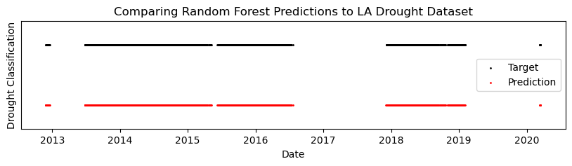

```python
## Predicting full dataset
# Regenerating model because of error when calling returned Random Forest model
# See https://stackoverflow.com/questions/71470896/returning-a-trained-scikit-learn-random-forest-model-from-a-function
rf_model = RandomForestClassifier().fit(X_train,y_train)
df_la['predict'] = rf_model.predict(X)
# acc = accuracy_score(df_la['target'], df_la['predict'])
# rec = recall_score(df_la['target'], df_la['predict'])
# f1 = f1_score(df_la['target'], df_la['predict'])
# print(acc, rec, f1)

## Plotting
plt.figure(figsize=(10, 2))
plt.title("Comparing Random Forest Predictions to LA Drought Dataset")
plt.scatter(df_la[df_la['target'] == 1]['date'], df_la[df_la['target'] == 1]['target'],color = 'black',s=1, label='Target')
plt.scatter(df_la[df_la['predict'] == 1]['date'], df_la[df_la['predict'] == 1]['predict'] - 0.05,color = 'red',s=1, label='Prediction')
plt.tick_params(axis='y', which='both', length=0)
plt.yticks([])
plt.ylabel('Drought Classification')
plt.xlabel('Date')
plt.ylim([0.93,1.02])
plt.legend()
plt.show()
```

## 3. Limitations

While the various models have proven accurate, there are always limitations to any machine learning model.

Since a supervised learning model must be trained, the resulting model is only valid if the future data reflects the training data. For example, this particular model is only valid for predicting drought in the Los Angeles area since it was trained on Los Angeles drought data. The model is invalid for predicting drought in the Amazon rainforest, for example.

The model is also limited to the chosen features including soil moisture, temperature, and groundwater level. If a new predictor were found (such as snowfall metrics or social indicators like water usage), the existing model would need to be re-trained for that predictor.

While this model relies on data collected since 2010, models based on older datasets may have intrinsic assumptions not detailed as their own predictors. For example, a model may consider groundwater depletion as an indicator of drought, but the model may not isolate the effects of growing population demand vs. reduction in precipitation as a cause. In essence, using a single variable without understanding the underlying causation inherently introduces assumptions (and therefore limitations) to the model.

Models may also not be deterministic and can find different solutions based on sampling, batch size, etc. In particular, there was wide variation in the neural network sensitivity analysis to draw neat conclusions about which architecture consistently performs most accurately.

## 4. Conclusion

While random forest performed best of the methods tests, decision trees and SVM could potentially be improved via hyperparameter tuning. Neural networks could similarly benefit from further sensitivity analysis, and more detailed analysis of sensitivity analysis could clarify trends in changing the number of layers or neurons.

This analysis focused on binary classification of drought conditions. However, as emphasized by the levels of drought severity provided by Drought Monitor resources, drought is a spectrum. Future analysis could consider the calculated Drought Severity and Coverage Index (DSCI), which describes drought severity as a single continuous variable. Modeling a continuous variable allows for regression methodologies, which could translate to time series prediction as well.

While it is easy to fall into the data science trap of looking at problems as purely theoretical, it is crucial to consider how accurate drought prediction models can help address future drought concerns or feed into wildfire specific models. It is certainly useful to understand how various models perform in Los Angeles to establish a methodology for other regions or data problems.

## 5. References

- "001N005W35B004S - 340804117221604." *USGS*, https://waterdata.usgs.gov/monitoring-location/340804117221604/#dataTypeId=continuous-72019-0&period=P7D&showMedian=true, Accessed 3 Mar. 2025
- "Comprehensive Statistics." *U.S. Drought Monitor*, https://droughtmonitor.unl.edu/DmData/DataDownload/ComprehensiveStatistics.aspx. Accessed 3 Mar. 2025.
- "Daily Summaries Station Details - NOAA Station USW00023174", *NOAA*, https://www.ncdc.noaa.gov/cdo-web/datasets/GHCND/stations/GHCND:USW00023174/detail, Accessed 3 Mar. 2025
- "The Department of Forestry and Fire Protection" *Cal FIRE*, https://www.fire.ca.gov. Accessed 3 Mar. 2025.
- "El Nino." *California Coastal Commission*, 18 Dec. 2023, https://www.coastal.ca.gov/climate/extreme-weather/el-nino/
- "Index of /data/us-climate-reference-network/access/derived-products/soil/soilanom" *NOAA - Climate Reference Network*, https://www.ncei.noaa.gov/data/us-climate-reference-network/access/derived-products/soil/soilanom/, Accessed 3 Mar. 2025
- Keeley, Jon. “How Santa Ana Winds Fueled the Deadly Fires in Southern California.” *University of California*, 10 Jan. 2025, www.universityofcalifornia.edu/news/how-santa-ana-winds-fueled-deadly-fires-southern-california.
- "Los Angeles R a Sepulveda Dam CA - 11092450." *USGS*, https://waterdata.usgs.gov/monitoring-location/11092450/#dataTypeId=continuous-00060-0&period=P365D&showMedian=false, Accessed 3 Mar. 2025
- "QuickFacts Los Angeles County, California." *United States Census Bureau*, https://www.census.gov/quickfacts/fact/table/losangelescountycalifornia/PST045223. Accessed 3 Mar. 2025.
- “Statistics.” *Cal FIRE*, www.fire.ca.gov/our-impact/statistics. Accessed 3 Mar. 2025.
- "Top 20 Most Destructive California Wildfires" *Cal FIRE*, https://34c031f8-c9fd-4018-8c5a-4159cdff6b0d-cdn-endpoint.azureedge.net/-/media/calfire-website/our-impact/fire-statistics/top20_destruction.pdf?rev=8d25d868e50f40aea60833642d65b449&hash=1DBAA251C9CC52EDC5AAEA2358158664. Accessed 3 Mar. 2025.